# STAT/MATH 495: Problem Set 03

Syed Abbas Shah

2017-09-26

# Question

For both `data1` and `data2` tibbles (a tibble is a data frame with some [metadata](https://blog.rstudio.com/2016/03/24/tibble-1-0-0#tibbles-vs-data-frames) attached):

- Find the splines model with the best out-of-sample predictive ability.
- Create a visualizaztion arguing why you chose this particular model.
- Create a visualizaztion of this model plotted over the given $(x_i, y_i)$ points for $i=1,\ldots,n=3000$.
- Give your estimate $\widehat{\sigma}$ of $\sigma$ where the noise component $\epsilon_i$ is distributed with mean 0 and standard deviation $\sigma$.

# General Strategy:

My strategy to approach these datasets will involve the following:

1. I will explore the datasets to visualize the relationship between the variables involved. Since there are only 2 substantive variables in these tibbles, it becomes easier as there is no choice. I will figure out effective ways to demonstrate the relationship.
2. I will fit a Spline Model to the entire dataset and tweak the degrees of freedom until I am satisfied with the fit (without using the in-built cv function).
3. I will do an initial crossvalidation with two folds, fit a spline model to the training set and apply it to the test set. Then, I will compute the RMSE’s for this. Following this, I will fit a spline model to the *test* set and predict the training set, computing a second RMSE. I will then average these two values. This will allow me to see what model to fit to the overall data as this model woul dhave a better out-of-sample validity.
4. I will then do a crossvalidation with 5 folds. That would entail making five models overall (training on k-1 subsets and testing on the remaining one, and repeating this process 5 times). I will then compute the average of the RMSE’s.
5. Based on all of these, I will estimate $\sigma$

# Data 1

### Exploratory Data Analysis:

Let’s first look at the data:

```
## # A tibble: 6 x 3
##      ID          x         y
##   <int>      <dbl>     <dbl>
## 1     1 52.4585218 -4.694998
## 2     2 63.6341266 19.854723
## 3     3 33.1341217 10.878075
## 4     4  0.1977558 -5.649503
## 5     5 36.7559002 24.449026
## 6     6 66.2841361 -3.776968
```

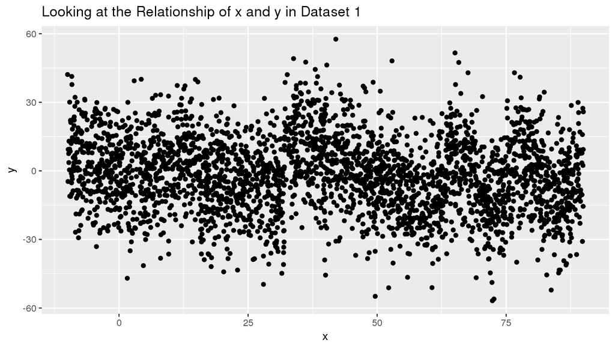

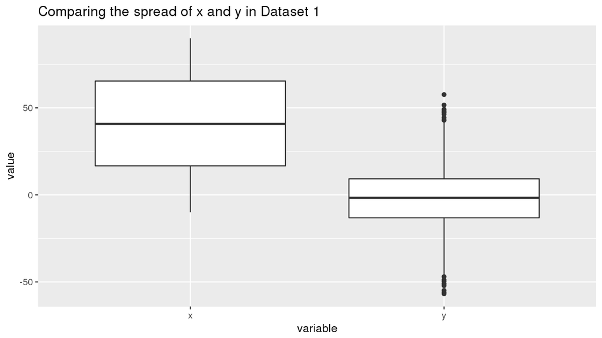

There’s a moderately weak relationship between the variables. The spread of x is greater than the spread of y. Clearly, a model which has reasonably high flexibility needs to be fit.

### Making a Function:

To make my work easier, I’m going to make one function that will fit the spline model and output the plot and the RMSE of the predictions.

```r
helpful.fn <- function(trainds,testds, df, plotyes = TRUE){ #inputs are training dataset, test dataset, df of spline model
x<- smooth.spline(trainds$x, trainds$y, df=df)
x1<- broom::augment(x)
plotx<- x1 %>%
  ggplot(aes(x=x)) +
  geom_point(aes(y=y)) +
  geom_line(aes(y=.fitted), col="red", size=1);
predictions <- predict(x,testds$x)
rmse<-(testds$y - predictions$y )^2%>%
  mean() %>%
  sqrt()
if(plotyes){
return(list(plotx, rmse))
}
else{
  return(rmse)
}
}
```

### Initial Crossvalidation:

Let’s start by dividing the dataset into two (with 50% each).

```r
set.seed(123)
indices <- sample(nrow(data1), nrow(data1)/2, replace=FALSE)
train <- data1[indices,]
test <- data1[-indices,]
```

First, I will fit a model on the training subset, and then apply it to the test set. I will then attempt to find which spline model minimizes the RMSE on the test set. Then, I will reverse the process by finding a model from the test set and applying it to the training one.

```
##  [1]  0.00000 15.98728 15.96217 15.89540 15.80093 15.70451 15.61420
##  [8] 15.53339 15.46353 15.40157 15.34447 15.28937 15.23462 15.18040
## [15] 15.12853 15.07971 15.03522 14.99620 14.96280 14.93442 14.91087
## [22] 14.89148 14.87600 14.86355 14.85371 14.84606 14.84035 14.83623
## [29] 14.83346 14.83185 14.83125 14.83152 14.83256 14.83426 14.83656
## [36] 14.83937 14.84265 14.84633 14.85037 14.85474 14.85939 14.86431
## [43] 14.86942 14.87475 14.88026 14.88592 14.89172 14.89762 14.90363
## [50] 14.90972
```

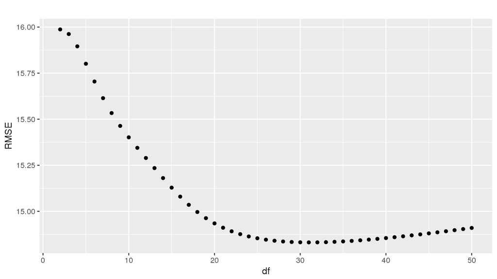

```
## [1] 30
```

This shows the the degrees of freedom at which the RMSE of the test set is lowest is 31 with an RMSE of 14.83125 .

Let’s Flip now.

```
##  [1]  0.00000 16.38155 16.35906 16.29555 16.20466 16.11193 16.02319
##  [8] 15.94234 15.87061 15.80647 15.74782 15.69244 15.63894 15.58726
## [15] 15.53860 15.49385 15.45397 15.41922 15.39005 15.36565 15.34562
## [22] 15.32951 15.31667 15.30630 15.29794 15.29117 15.28573 15.28129
## [29] 15.27766 15.27470 15.27227 15.27028 15.26870 15.26748 15.26659
## [36] 15.26599 15.26568 15.26564 15.26585 15.26631 15.26700 15.26792
## [43] 15.26905 15.27040 15.27196 15.27371 15.27564 15.27776 15.28005
## [50] 15.28251
```

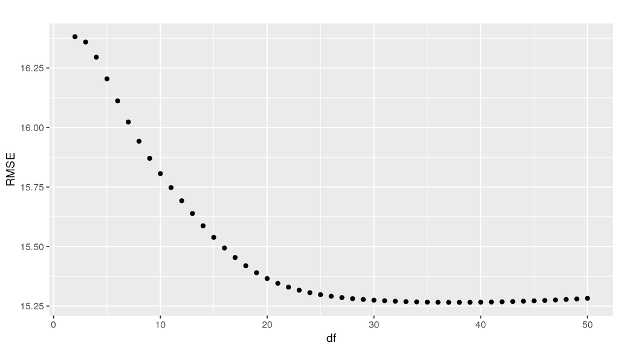

```
## [1] 37
```

This shows the the degrees of freedom at which the RMSE of the test set is lowest is 38 with an RMSE of 15.26564

The average of the two RMSE scores is 15.04844. I’d probably take a df value of 34 which is midway between the two optimal degrees of freedom values computed above.

Before we choose this model, let’s try 5-fold crossvalidation.

### Crossvalidation with 5 folds:

Now we can attempt to do crossvalidation with multiple folds to test whether which model reduces the RMSE the most.

```r
set.seed(3400)
indices <- sample(nrow(data1), nrow(data1), replace=FALSE)
splits<-split(indices, ceiling(seq_along(indices)/600))
splits<-as.data.frame(splits)
d1a <- data1[splits$X1,]
d1b <- data1[splits$X2,]
d1c <- data1[splits$X3,]
d1d <- data1[splits$X4,]
d1e <- data1[splits$X5,]
```

Step 1:

Test on d1a and train on all the rest.

```r
y<- data1[-splits$X1,]
xx=0;
for(i in 2:50){
xx[i]<-helpful.fn(y,d1a,i, FALSE)
}
xx
```

```
##  [1]  0.00000 16.86523 16.85366 16.79618 16.70023 16.59956 16.50642
##  [8] 16.42447 16.35195 16.28659 16.22399 16.16185 16.09913 16.03548
## [15] 15.97318 15.91339 15.85765 15.80745 15.76310 15.72491 15.69183
## [22] 15.66438 15.64115 15.62220 15.60649 15.59388 15.58387 15.57585
## [29] 15.56975 15.56520 15.56196 15.55985 15.55868 15.55831 15.55861
## [36] 15.55948 15.56086 15.56262 15.56477 15.56719 15.56986 15.57274
## [43] 15.57576 15.57897 15.58231 15.58581 15.58937 15.59300 15.59672
## [50] 15.60049
```

```r
xx<-as.data.frame(xx)
xx<-xx[-1,];
xx<-as.data.frame(xx)
xx$df <- seq(from=2,to=50, by=1)
which.min(xx[,1])
```

```
## [1] 33
```

Step 2: Test on d1b and train on all the rest.

```
##  [1]  0.00000 16.15824 16.14015 16.09469 16.03599 15.97388 15.90551
##  [8] 15.83664 15.77183 15.71261 15.65635 15.60118 15.54596 15.48995
## [15] 15.43520 15.38223 15.33238 15.28723 15.24636 15.21032 15.17888
## [22] 15.15179 15.12798 15.10762 15.08972 15.07438 15.06087 15.04890
## [29] 15.03847 15.02925 15.02107 15.01381 15.00734 15.00156 14.99646
## [36] 14.99181 14.98770 14.98404 14.98079 14.97790 14.97535 14.97315
## [43] 14.97120 14.96951 14.96808 14.96688 14.96591 14.96515 14.96458
## [50] 14.96420
```

```
## [1] 49
```

Minimum RMSE is 14.96420. df= 50

Step 3:

Test on d1c and train on all the rest

```
##  [1]  0.00000 15.90903 15.88485 15.83013 15.75593 15.67416 15.58729
##  [8] 15.50204 15.42160 15.34674 15.27480 15.20461 15.13573 15.06792
## [15] 15.00386 14.94401 14.89051 14.84411 14.80426 14.77149 14.74485
## [22] 14.72384 14.70719 14.69458 14.68499 14.67809 14.67319 14.66990
## [29] 14.66797 14.66708 14.66702 14.66762 14.66876 14.67030 14.67216
## [36] 14.67430 14.67667 14.67917 14.68179 14.68450 14.68727 14.69005
## [43] 14.69289 14.69574 14.69858 14.70145 14.70426 14.70704 14.70979
## [50] 14.71249
```

```
## [1] 30
```

Minimum RMSE is 14.66702. DF = 31

Step 4: Test on d1d and train on all the rest

```
##  [1]  0.00000 16.07646 16.04653 15.97358 15.86926 15.75954 15.65327
##  [8] 15.55559 15.46742 15.38830 15.31558 15.24693 15.18127 15.11848
## [15] 15.06010 15.00679 14.95964 14.91957 14.88631 14.85932 14.83780
## [22] 14.82114 14.80809 14.79820 14.79055 14.78477 14.78029 14.77676
## [29] 14.77400 14.77177 14.76992 14.76835 14.76697 14.76573 14.76460
## [36] 14.76354 14.76252 14.76156 14.76062 14.75972 14.75885 14.75801
## [43] 14.75720 14.75642 14.75568 14.75496 14.75429 14.75367 14.75310
## [50] 14.75257
```

```
## [1] 49
```

Step 5: Test on d1e and train on all the rest

```
##  [1]  0.00000 15.83702 15.81292 15.73651 15.62965 15.53242 15.45513
##  [8] 15.39766 15.35603 15.32627 15.30360 15.28465 15.26786 15.25268
## [15] 15.23966 15.22948 15.22255 15.21899 15.21851 15.22062 15.22476
## [22] 15.23031 15.23691 15.24399 15.25142 15.25884 15.26610 15.27331
## [29] 15.28021 15.28686 15.29326 15.29941 15.30535 15.31107 15.31660
## [36] 15.32190 15.32707 15.33216 15.33704 15.34178 15.34638 15.35086
## [43] 15.35521 15.35943 15.36354 15.36753 15.37140 15.37517 15.37880
## [50] 15.38236
```

```
## [1] 18
```

Minimum RMSE is 15.21851. df = 19

[output not shown]

I’d probably pick the mean of the 5 degrees of freedom for the final model, which is 36.8.

### Conclusion:

The Model I select has 36.8 degrees of freedom. It’s visualized below:

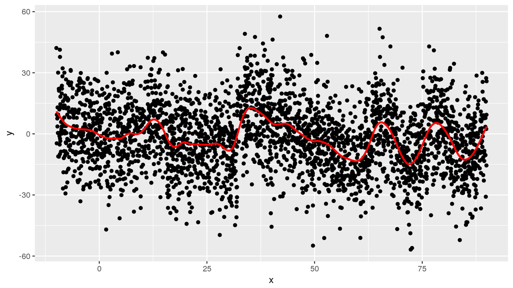

# Data 2

For this Dataset, we will follow the same process.

### Exploratory Data Analysis:

Firstly, let’s examine the data.

```r
head(data2)
```

```
## # A tibble: 6 x 3
##      ID          x         y
##   <int>      <dbl>     <dbl>
## 1     1 52.4585218 -4.127757
## 2     2 63.6341266 33.821437
## 3     3 33.1341217  8.944431
## 4     4  0.1977558 -7.617335
## 5     5 36.7559002 33.977201
## 6     6 66.2841361 -9.548001
```

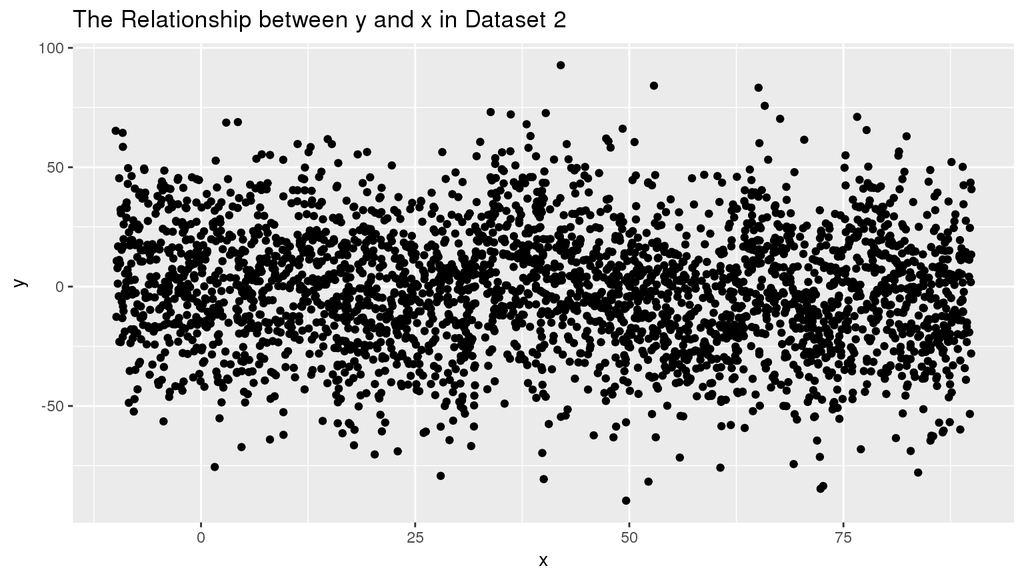

```r
ggplot(data = data2, aes(x=x, y=y)) + geom_point()  + theme(legend.position="none") + labs(title="The Relationship between y and x in Dataset 2")
```

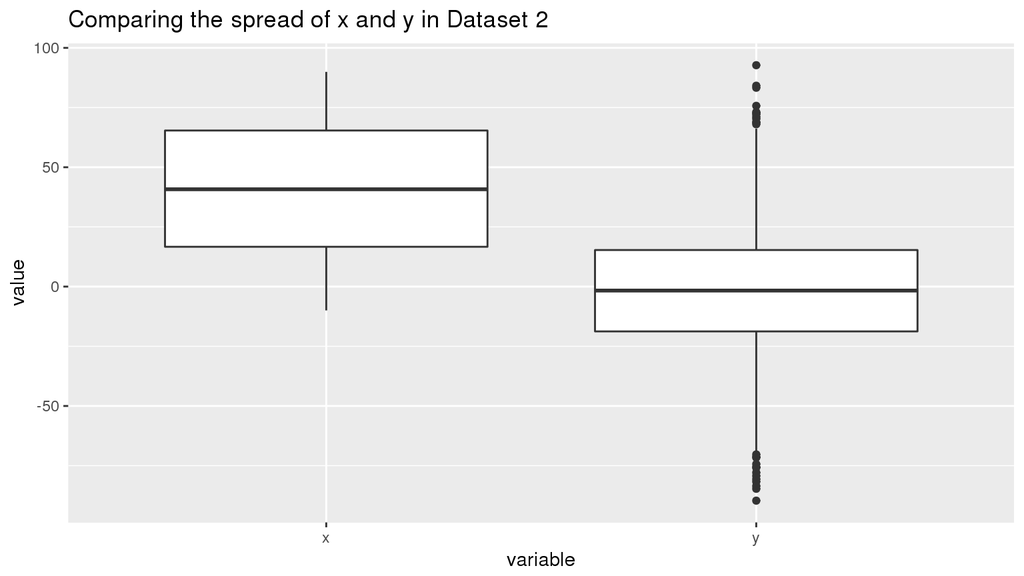

```r
 melt(data2) %>%
 filter(!variable=="ID") %>%
ggplot(aes(x=variable, y=value)) + geom_boxplot()  + theme(legend.position="none") + labs(title="Comparing the spread of x and y in Dataset 2")
```

Y has some extreme outliers in both directions. The relationship seems weak (in linear terms) and definitely needs a flexible model

### Initial Crossvalidation:

Let’s start by dividing the dataset into two (with 50% each).

```r
set.seed(13)
indices <- sample(nrow(data2), nrow(data2)/2, replace=FALSE)
train <- data2[indices,]
test <- data2[-indices,]
```

First, I will fit a model on the training subset, and then apply it to the test set. I will then attempt to find which spline model minimizes the RMSE on the test set. Then, I will reverse the process by finding a model from the test set and applying it to the training one.

```
##  [1]  0.00000 25.81277 25.80415 25.76789 25.71532 25.66701 25.62962
##  [8] 25.60207 25.58010 25.56014 25.54029 25.51948 25.49722 25.47377
## [15] 25.45024 25.42728 25.40618 25.38753 25.37178 25.35884 25.34865
## [22] 25.34107 25.33581 25.33246 25.33076 25.33047 25.33135 25.33320
## [29] 25.33586 25.33916 25.34304 25.34740 25.35219 25.35729 25.36266
## [36] 25.36829 25.37413 25.38017 25.38638 25.39274 25.39927 25.40594
## [43] 25.41275 25.41970 25.42679 25.43398 25.44138 25.44889 25.45654
## [50] 25.46434
```

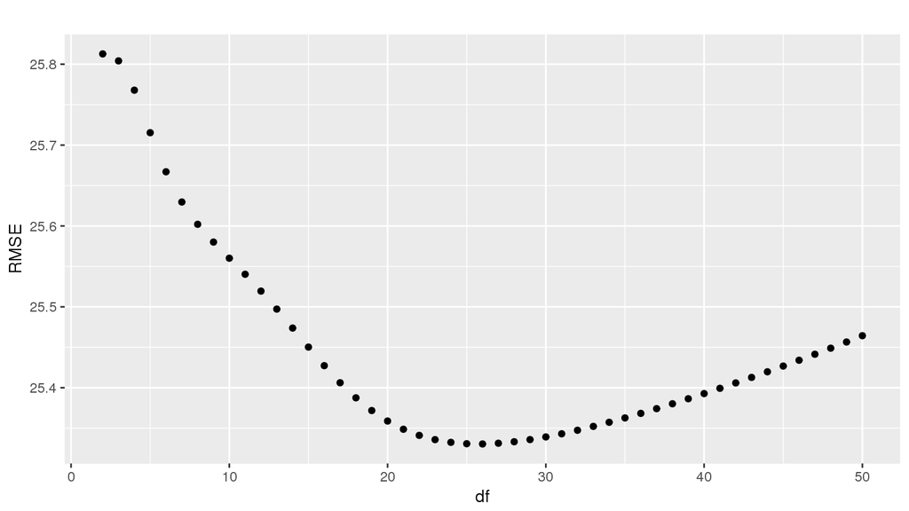

```
## [1] 25
```

This shows the the degrees of freedom at which the RMSE of the test set is lowest is 26 with an RMSE of 25.33047.

Let’s Flip now.

```
##  [1]  0.00000 25.37357 25.36387 25.33046 25.28877 25.24986 25.20970
##  [8] 25.16844 25.12869 25.09106 25.05468 25.01860 24.98215 24.94581
## [15] 24.91093 24.87806 24.84856 24.82295 24.80157 24.78412 24.77055
## [22] 24.76045 24.75362 24.74950 24.74778 24.74816 24.75033 24.75403
## [29] 24.75904 24.76515 24.77214 24.78004 24.78853 24.79758 24.80709
## [36] 24.81697 24.82718 24.83765 24.84834 24.85922 24.87026 24.88144
## [43] 24.89275 24.90416 24.91560 24.92718 24.93887 24.95058 24.96236
## [50] 24.97419
```

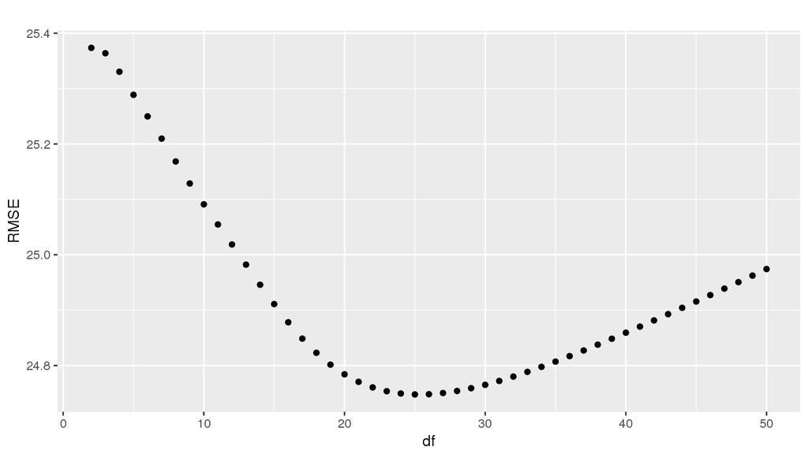

```
## [1] 24
```

This shows the the degrees of freedom at which the RMSE of the test set is lowest is 25 with an RMSE of 24.74778.

The average RMSE from this 2-fold cv is 25.03912. Before we choose this model, let’s try five-fold crossvalidation.

### Crossvalidation with 5 folds:

Now we can attempt to do crossvalidation with multiple folds to test whether which model reduces the RMSE the most.

```r
set.seed(600)
indices <- sample(nrow(data2), nrow(data2), replace=FALSE)
splits<-split(indices, ceiling(seq_along(indices)/600))
splits<-as.data.frame(splits)
d2a <- data2[splits$X1,]
d2b <- data2[splits$X2,]
d2c <- data2[splits$X3,]
d2d <- data2[splits$X4,]
d2e <- data2[splits$X5,]
```

Step 1:

Test on d1a and train on all the rest.

```
##  [1]  0.00000 24.80611 24.80264 24.78669 24.76262 24.73160 24.69449
##  [8] 24.65789 24.62392 24.59120 24.55764 24.52179 24.48368 24.44418
## [15] 24.40526 24.36811 24.33417 24.30409 24.27871 24.25736 24.24031
## [22] 24.22674 24.21626 24.20852 24.20291 24.19920 24.19694 24.19592
## [29] 24.19592 24.19676 24.19830 24.20042 24.20302 24.20601 24.20935
## [36] 24.21305 24.21695 24.22106 24.22535 24.22979 24.23436 24.23898
## [43] 24.24375 24.24860 24.25351 24.25846 24.26352 24.26854 24.27359
## [50] 24.27861
```

```
## [1] 27
```

Minimum RMSE is 24.19592. df = 28

Step 2: Test on d1b and train on all the rest.

```
##  [1]  0.00000 24.31104 24.29554 24.24055 24.16088 24.08229 24.01401
##  [8] 23.95912 23.91802 23.88854 23.86689 23.84989 23.83558 23.82315
## [15] 23.81278 23.80466 23.79906 23.79604 23.79533 23.79657 23.79931
## [22] 23.80318 23.80784 23.81292 23.81835 23.82382 23.82938 23.83494
## [29] 23.84049 23.84594 23.85134 23.85669 23.86200 23.86725 23.87252
## [36] 23.87782 23.88318 23.88852 23.89390 23.89934 23.90478 23.91035
## [43] 23.91601 23.92175 23.92759 23.93359 23.93962 23.94575 23.95198
## [50] 23.95832
```

```
## [1] 18
```

Minimum RMSE is 23.79533 DF = 19

Step 3:

Test on d1c and train on all the rest

```
##  [1]  0.00000 25.09705 25.10038 25.10232 25.10308 25.08994 25.05923
##  [8] 25.02137 24.98370 24.94883 24.91579 24.88365 24.85195 24.82048
## [15] 24.79063 24.76284 24.73792 24.71662 24.69861 24.68410 24.67265
## [22] 24.66396 24.65744 24.65291 24.64989 24.64818 24.64746 24.64757
## [29] 24.64833 24.64962 24.65132 24.65336 24.65568 24.65822 24.66094
## [36] 24.66387 24.66693 24.67012 24.67344 24.67689 24.68046 24.68411
## [43] 24.68791 24.69184 24.69588 24.70008 24.70435 24.70873 24.71322
## [50] 24.71780
```

```
## [1] 26
```

Minimum RMSE is 24.64746. DF = 27

Step 4: Test on d1d and train on all the rest

```
##  [1]  0.00000 26.63052 26.62318 26.59183 26.53602 26.47408 26.41310
##  [8] 26.35420 26.29588 26.23823 26.18041 26.12280 26.06577 26.00917
## [15] 25.95498 25.90318 25.85538 25.81212 25.77295 25.73879 25.70843
## [22] 25.68244 25.65957 25.64006 25.62298 25.60847 25.59587 25.58493
## [29] 25.57564 25.56772 25.56099 25.55534 25.55063 25.54677 25.54370
## [36] 25.54125 25.53945 25.53820 25.53744 25.53714 25.53725 25.53772
## [43] 25.53854 25.53966 25.54107 25.54276 25.54467 25.54679 25.54912
## [50] 25.55164
```

```
## [1] 39
```

Minimum RMSE is 25.53714. df = 40

Step 5: Test on d1e and train on all the rest

```
##  [1]  0.00000 26.80517 26.78689 26.73182 26.65712 26.59578 26.55685
##  [8] 26.53502 26.52206 26.51228 26.50233 26.49087 26.47798 26.46412
## [15] 26.45044 26.43776 26.42681 26.41814 26.41185 26.40791 26.40606
## [22] 26.40608 26.40767 26.41052 26.41445 26.41916 26.42446 26.43034
## [29] 26.43653 26.44296 26.44957 26.45629 26.46306 26.46984 26.47659
## [36] 26.48321 26.48992 26.49639 26.50290 26.50924 26.51547 26.52159
## [43] 26.52752 26.53343 26.53924 26.54501 26.55063 26.55615 26.56160
## [50] 26.56698
```

```
## [1] 20
```

Minimum RMSE is 26.40606. df = 21

The Average RMSE from these five models is : 24.91638.

```
## [1] 24.91638
```

I’d probably pick the mean of the 5 degrees of freedom for the final model, which is 27

### Conclusion:

The Model I select has 27 degrees of freedom. It’s visualized below:

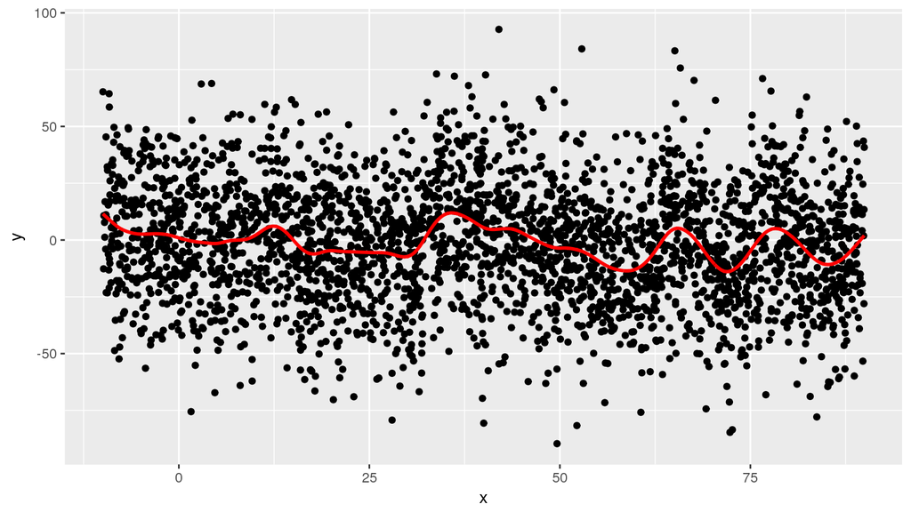

Since RMSE is the standard deviation of unexplained variance, I estimate that sigma would be around 24.91638.